# Temperature Climate Forecasting

By : Bayu Raka Janasri

6/2/2021

# 1 Introduction

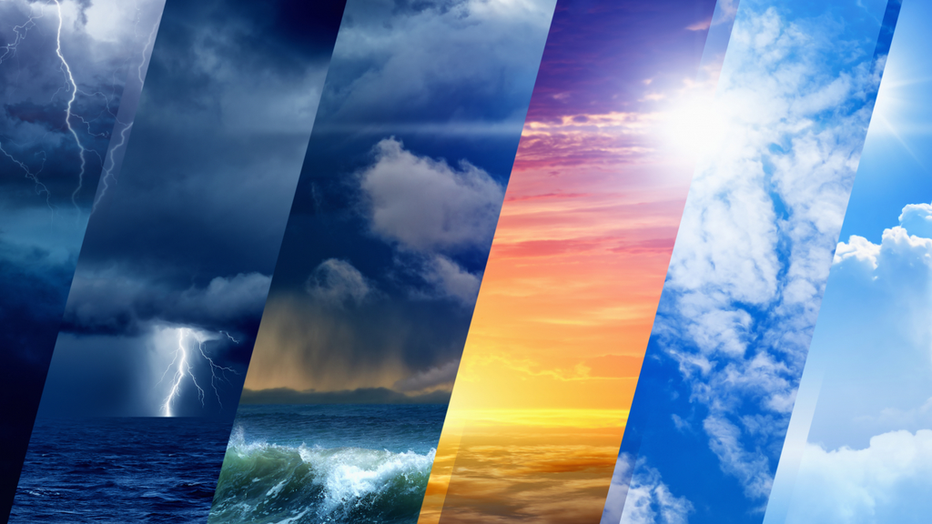

Hello everyone !!!

The Dataset is Indian climate, this dataset provides data from 1st January 2013 to 24th April 2017 in the city of Delhi, India. The 4 parameters here are meantemp, humidity, wind_speed, meanpressure. At this moment we will build some models for predict temperature using this dataset.

Source: https://www.kaggle.com/sumanthvrao/daily-climate-time-series-data.

# 2 Data Preparation

## 2.1 Import Library

```r
library(dplyr) # for data wrangling
library(lubridate) # date manipulation
library(TSstudio) # time series interactive viz
library(forecast) # time series library
library(tseries) # for adf.test
```

## 2.2 Read Data

From the dataset there are already train and data test, we don’t have to split them into two data anymore.

### 2.2.1 Import data train

```r
climate_train <- read.csv("DailyDelhiClimateTrain.csv")
head(climate_train)
```

|  | date | meantemp | humidity | wind_speed | meanpressure |
| --- | --- | --- | --- | --- | --- |
| 1 | 2013-01-01 | 10.000000 | 84.50000 | 0.000000 | 1015.667 |
| 2 | 2013-01-02 | 7.400000 | 92.00000 | 2.980000 | 1017.800 |
| 3 | 2013-01-03 | 7.166667 | 87.00000 | 4.633333 | 1018.667 |
| 4 | 2013-01-04 | 8.666667 | 71.33333 | 1.233333 | 1017.167 |
| 5 | 2013-01-05 | 6.000000 | 86.83333 | 3.700000 | 1016.500 |
| 6 | 2013-01-06 | 7.000000 | 82.80000 | 1.480000 | 1018.000 |

### 2.2.2 Import data test

```r
climate_test <- read.csv("DailyDelhiClimateTest.csv")
head(climate_test)
```

|  | date | meantemp | humidity | wind_speed | meanpressure |
| --- | --- | --- | --- | --- | --- |
| 1 | 2017-01-01 | 15.91304 | 85.86957 | 2.743478 | 59.000 |
| 2 | 2017-01-02 | 18.50000 | 77.22222 | 2.894444 | 1018.278 |
| 3 | 2017-01-03 | 17.11111 | 81.88889 | 4.016667 | 1018.333 |
| 4 | 2017-01-04 | 18.70000 | 70.05000 | 4.545000 | 1015.700 |
| 5 | 2017-01-05 | 18.38889 | 74.94444 | 3.300000 | 1014.333 |
| 6 | 2017-01-06 | 19.31818 | 79.31818 | 8.681818 | 1011.773 |

## 2.3 Check data type

```r
glimpse(climate_train)
```

```
## Rows: 1,462
## Columns: 5
## $ date         <chr> "2013-01-01", "2013-01-02", "2013-01-03", "2013-01-04", "…
## $ meantemp     <dbl> 10.000000, 7.400000, 7.166667, 8.666667, 6.000000, 7.0000…
## $ humidity     <dbl> 84.50000, 92.00000, 87.00000, 71.33333, 86.83333, 82.8000…
## $ wind_speed   <dbl> 0.0000000, 2.9800000, 4.6333333, 1.2333333, 3.7000000, 1.…
## $ meanpressure <dbl> 1015.667, 1017.800, 1018.667, 1017.167, 1016.500, 1018.00…
```

Time series is a method of analyzing and processing data in which the values are affected by time. The action of predicting future values based on its value in the previous period of time is called forecasting.

The data which formatted into a time series (ts) object must have some characteristics:

- no missing intervals
- no missing values
- data should be ordered by time

## 2.4 Check Missing Value

We have to check if there is any missing values in our dataset. There is no missing value on our dataset.

```r
anyNA(climate_train)
```

```
## [1] FALSE
```

```r
anyNA(climate_test)
```

```
## [1] FALSE
```

## 2.5 Check data range

We have to check our data range. This is important for time series prediction, it can help us for choosing right frequency.

```r
range(climate_train$date)
```

```
## [1] "2013-01-01" "2017-01-01"
```

```r
range(climate_test$date)
```

```
## [1] "2017-01-01" "2017-04-24"
```

## 2.6 Check missing interval

```r
interval(start = head(climate_train$date)[1], end = tail(climate_train$date)[1])
```

```
## [1] 2013-01-01 UTC--2016-12-27 UTC
```

```r
interval(start = head(climate_test$date)[1], end = tail(climate_test$date)[1])
```

```
## [1] 2017-01-01 UTC--2017-04-19 UTC
```

# 3 Data Pre-processing

## 3.1 Feature Engineering

### 3.1.1 Selecting column

Take date and meantemp column form test data.

```r
test_clean <- climate_test %>%
                select(date, meantemp)
```

Take date and meantemp column for train data.

```r
train_clean <- climate_train %>%
                select(date, meantemp)
```

### 3.1.2 Create time series object for data train

After creating ts object, we can plot our object and see the graph.

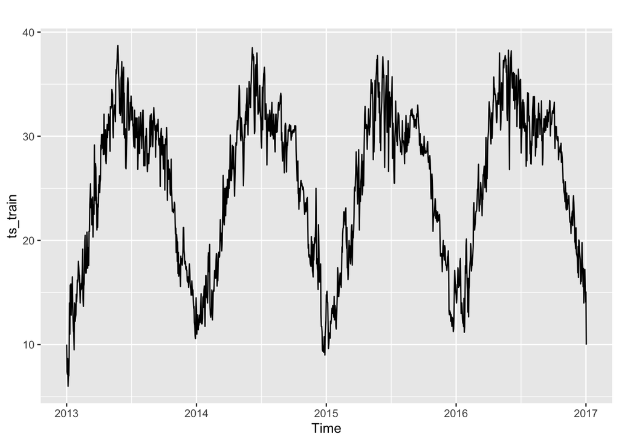

```r
ts_train <- ts(data = train_clean$meantemp,
                start = c(2013,01),
                frequency = 365)
autoplot(ts_train)
```

### Create time series object for data test

After creating ts object, we can plot our object and see the graph.

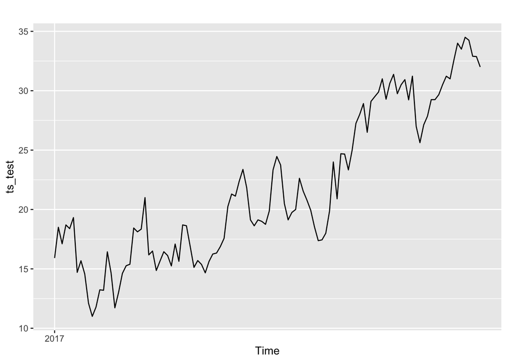

```r
ts_test <- ts(data = test_clean$meantemp,
                start = c(2017,01),
                frequency = 365)
autoplot(ts_test)
```

### Decompose

Decomposing a time series means separating it into its constituent components.

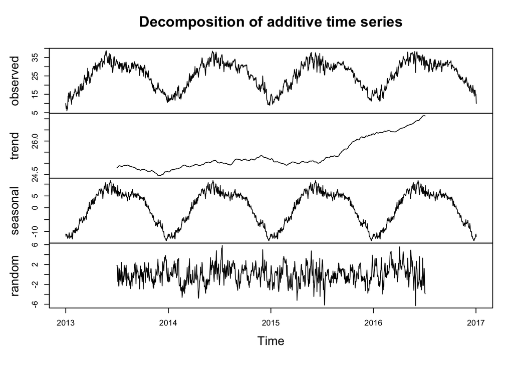

```r
climate_dc <- decompose(ts_train)
plot(climate_dc)
```

From our graph above we conclude our dataset have trend and seasonal. This is important to know what is our data characteristic, we choose their model based on their character.

# 4 Modeling

## 4.1 Holt-Winters Model

### 4.1.1 Create Holt-Winters Model

```r
climate_hw <- HoltWinters(ts_train,seasonal = "additive")
climate_hw
```

```
## Holt-Winters exponential smoothing with trend and additive seasonal component.
##
## Call:
## HoltWinters(x = ts_train, seasonal = "additive")
##
## Smoothing parameters:
##  alpha: 0.7137593
##  beta : 0
##  gamma: 1
##
## Coefficients:
##                [,1]
## a     23.2059477677
## b      0.0007786026
## s1   -11.9533349288
## s2   -11.5762825721
## s3   -11.9041600160
## s4   -12.4673985971
## s5   -13.1139452002
## s6   -13.2679980348
## s7   -12.0927171628
## s8   -12.0040252582
## s9   -12.1629632245
## s10  -11.3536225915
## s11  -10.6396502270
## s12  -10.9244341162
## s13  -12.2023082443
## s14  -11.8208475341
## s15  -11.9809092479
## s16  -12.3595377689
## s17  -11.2499619086
## s18  -10.5631695277
## s19  -10.6830829034
## s20  -10.2530733677
## s21   -8.3192899413
## s22  -10.9730260524
## s23  -11.5427618181
## s24  -10.0070860460
## s25   -8.2999617144
## s26   -8.7416898276
```

[output cut: 324 more lines]

```
## s351  -9.8526220257
## s352  -9.0038355291
## s353  -8.8693315666
## s354  -9.9496447456
## s355  -9.9875774545
## s356 -10.9735567202
## s357 -10.3108537618
## s358 -11.6891438193
## s359 -10.4388489818
## s360 -11.9443450632
## s361 -12.7326185746
## s362 -13.3302856296
## s363 -12.1500512417
## s364 -10.7694930750
## s365 -13.2059477677
```

### 4.1.2 Forecast model

```r
climate_forecast <- forecast(climate_hw, h=114)
climate_forecast
```

```
##           Point Forecast      Lo 80    Hi 80       Lo 95    Hi 95
## 2017.0055      11.253391  8.8448898 13.66189  7.56990607 14.93688
## 2017.0082      11.631222  8.6721429 14.59030  7.10570078 16.15674
## 2017.0110      11.304124  7.8819279 14.72632  6.07032691 16.53792
## 2017.0137      10.741664  6.9119515 14.57138  4.88462432 16.59870
## 2017.0164      10.095896  5.8980430 14.29375  3.67583403 16.51596
## 2017.0192       9.942621  5.4064073 14.47884  3.00508059 16.88016
## 2017.0219      11.118681  6.2676490 15.96971  3.69966787 18.53769
## 2017.0247      11.208151  6.0615232 16.35478  3.33706280 19.07924
## 2017.0274      11.049992  5.6238466 16.47614  2.75141882 19.34857
## 2017.0301      11.860111  6.1681586 17.55206  3.15502087 20.56520
## 2017.0329      12.574862  6.6289731 18.52075  3.48140963 21.66831
## 2017.0356      12.290857  6.1014411 18.48027  2.82496228 21.75675
## 2017.0384      11.013761  4.5900444 17.43748  1.18953406 20.83799
## 2017.0411      11.396001  4.7462329 18.04577  1.22605851 21.56594
## 2017.0438      11.236718  4.3683347 18.10510  0.73243248 21.74100
## 2017.0466      10.858868  3.7786166 17.93912  0.03055815 21.68718
## 2017.0493      11.969222  4.6832612 19.25518  0.82630651 23.11214
## 2017.0521      12.656793  5.1707729 20.14281  1.20791326 24.10567
## 2017.0548      12.537658  4.8567880 20.21853  0.79078082 24.28454
## 2017.0575      12.968446  5.0975481 20.83934  0.93094620 25.00595
## 2017.0603      14.903008  6.8465631 22.95945  2.58173851 27.22428
## 2017.0630      12.250051  4.0122367 20.48787 -0.34859877 24.84870
## 2017.0658      11.681094  3.2658187 20.09637 -1.18895890 24.55115
## 2017.0685      13.217548  4.6284780 21.80662  0.08169883 26.35340
## 2017.0712      14.925451  6.1660334 23.68487  1.52907774 28.32182
## 2017.0740      14.484502  5.5579866 23.41102  0.83257496 28.13643
## 2017.0767      14.759192  5.6686508 23.84973  0.85640887 28.66198
## 2017.0795      14.167724  4.9160636 23.41938  0.01853058 28.31692
## 2017.0822      13.094642  3.6846213 22.50466 -1.29674265 27.48603
## 2017.0849      12.827346  3.2615861 22.39311 -1.80222116 27.45691
## 2017.0877      13.800582  4.0815784 23.51959 -1.06335123 28.66452
## 2017.0904      14.863798  4.9939294 24.73367 -0.23086328 29.95846
## 2017.0932      16.973466  6.9550040 26.99193  1.65155079 32.29538
## 2017.0959      15.151617  4.9867340 25.31650 -0.39422998 30.69746
## 2017.0986      17.188190  6.8789650 27.49741  1.42159109 32.95479
## 2017.1014      17.923080  7.4715064 28.37465  1.93877768 33.90738
## 2017.1041      15.648207  5.0561978 26.24022 -0.55087312 31.84729
## 2017.1068      13.480211  2.7496038 24.21082 -2.93083655 29.89126
## 2017.1096      11.991050  1.1236128 22.85849 -4.62926120 28.61136
```

[output cut: 60 more lines]

```
## 2017.2767      25.658862  8.3853917 42.93233 -0.75863106 52.07635
## 2017.2795      25.839524  8.4807213 43.19833 -0.70847392 52.38752
## 2017.2822      26.733521  9.2898021 44.17724  0.05565536 53.41139
## 2017.2849      27.764615 10.2363925 45.29284  0.95751195 54.57172
## 2017.2877      26.326777  8.7144563 43.93910 -0.60894331 53.26250
## 2017.2904      26.633076  8.9370563 44.32910 -0.43065085 53.69680
## 2017.2932      24.657690  6.8783646 42.43701 -2.53344156 51.84882
## 2017.2959      24.738707  6.8764659 42.60095 -2.57923359 52.05665
## 2017.2986      25.146979  7.2022042 43.09175 -2.29718574 52.59114
## 2017.3014      25.745508  7.7185774 43.77244 -1.82430303 53.31532
## 2017.3041      26.688301  8.5795882 44.79701 -1.00658544 54.38319
## 2017.3068      27.071620  8.8814920 45.26175 -0.74778014 54.89102
## 2017.3096      27.307823  9.0366428 45.57900 -0.63553581 55.25118
## 2017.3123      28.099498  9.7476229 46.45137  0.03272736 56.16627
## 2017.3151      28.985223 10.5530074 47.41744  0.79558180 57.17486
```

### 4.1.3 Check Accuracy

```r
forecast::accuracy(climate_forecast, ts_test)
```

```
##                        ME     RMSE      MAE       MPE      MAPE      MASE
## Training set -0.002952318 1.878509 1.317623 -0.254612  5.509781 0.5153414
## Test set      3.947982827 4.875027 4.125055 17.527790 18.548411 1.6133681
##                   ACF1 Theil's U
## Training set 0.1324813        NA
## Test set     0.7569823  2.528038
```

## 4.2 Arima Model

Before creating arima model, we have to make sure our data is stationary by using `adf.test()` from library `tseries`.

### 4.2.1 Check stationary data

```r
adf.test(ts_train)
```

```
##
##  Augmented Dickey-Fuller Test
##
## data:  ts_train
## Dickey-Fuller = -1.8526, Lag order = 11, p-value = 0.6407
## alternative hypothesis: stationary
```

Our `p-value > 0.05` that means our data is not stationer. If our data is not stationer we have to differencing.

```r
ts_train_diff <- ts_train %>% diff()
adf.test(ts_train_diff)
```

```
##
##  Augmented Dickey-Fuller Test
##
## data:  ts_train_diff
## Dickey-Fuller = -14.011, Lag order = 11, p-value = 0.01
## alternative hypothesis: stationary
```

After differencing our `p-value < 0.05`, it means our data already stationer.

### 4.2.2 Create Arima model

```r
climate_auto <- auto.arima(ts_train, seasonal = T)
climate_auto
```

```
## Series: ts_train
## ARIMA(3,1,1)(0,1,0)[365]
##
## Coefficients:
##          ar1     ar2      ar3      ma1
##       0.7188  0.0102  -0.0375  -0.9883
## s.e.  0.0311  0.0373   0.0311   0.0081
##
## sigma^2 estimated as 4.591:  log likelihood=-2392.92
## AIC=4795.84   AICc=4795.9   BIC=4820.84
```

### 4.2.3 Forecast Arima

```r
climate_auto_f <- forecast(climate_auto, h=114)
climate_auto_f
```

```
##           Point Forecast     Lo 80    Hi 80     Lo 95    Hi 95
## 2017.0055       12.12254  9.376510 14.86857  7.922850 16.32223
## 2017.0082       14.66313 11.262423 18.06384  9.462196 19.86407
## 2017.0110       15.76459 12.046968 19.48221 10.078977 21.45020
## 2017.0137       17.98450 14.127026 21.84196 12.085005 23.88399
## 2017.0164       18.18871 14.266076 22.11135 12.189558 24.18787
## 2017.0192       16.85897 12.904832 20.81310 10.811640 22.90629
## 2017.0219       17.40756 13.437174 21.37794 11.335382 23.47973
## 2017.0247       17.29901 13.319572 21.27845 11.212983 23.38504
## 2017.0274       17.50375 13.518768 21.48872 11.409248 23.59824
## 2017.0301       19.80514 15.816442 23.79385 13.704951 25.90534
## 2017.0329       20.10494 16.113490 24.09638 14.000546 26.20933
## 2017.0356       17.42212 13.428477 21.41576 11.314371 23.52986
## 2017.0384       14.87337 10.877862 18.86889  8.762766 20.98398
## 2017.0411       15.48224 11.485049 19.47943  9.369065 21.59541
## 2017.0438       15.88795 11.889204 19.88670  9.772396 22.00350
## 2017.0466       15.15830 11.158070 19.15853  9.040477 21.27612
## 2017.0493       14.25115 10.249483 18.25281  8.131131 20.37116
## 2017.0521       13.96220  9.959131 17.96526  7.840036 20.08436
## 2017.0548       14.08402 10.079565 18.08847  7.959736 20.20830
## 2017.0575       13.63048  9.624661 17.63631  7.504106 19.75686
## 2017.0603       16.33506 12.327873 20.34225 10.206596 22.46352
## 2017.0630       13.08532  9.076778 17.09387  6.954783 19.21586
## 2017.0658       13.56466  9.554760 17.57456  7.432048 19.69727
## 2017.0685       16.46060 12.449351 20.47185 10.325923 22.59528
## 2017.0712       19.48151 15.468905 23.49411 13.344762 25.61825
## 2017.0740       18.75536 14.741411 22.76931 12.616554 24.89417
## 2017.0767       21.46075 17.445450 25.47605 15.319879 27.60162
## 2017.0795       22.04112 18.024479 26.05777 15.898195 28.18405
## 2017.0822       19.27328 15.255287 23.29127 13.128291 25.41827
## 2017.0849       17.74444 13.725103 21.76378 11.597395 23.89149
## 2017.0877       17.16496 13.144276 21.18564 11.015855 23.31406
## 2017.0904       15.02329 11.001268 19.04532  8.872136 21.17445
## 2017.0932       18.26193 14.238562 22.28530 12.108718 24.41515
## 2017.0959       14.56496 10.540250 18.58968  8.409695 20.72023
## 2017.0986       17.23163 13.205575 21.25769 11.074308 23.38896
## 2017.1014       17.52330 13.495899 21.55070 11.363922 23.68268
## 2017.1041       18.98921 14.960466 23.01795 12.827779 25.15064
## 2017.1068       19.66753 15.637446 23.69762 13.504049 25.83101
## 2017.1096       20.03163 16.000208 24.06306 13.866100 26.19717
```

[output cut: 60 more lines]

```
## 2017.2767       31.69830 27.585878 35.81072 25.408893 37.98771
## 2017.2795       32.09830 27.984564 36.21204 25.806883 38.38972
## 2017.2822       33.64830 29.533249 37.76335 27.354873 39.94173
## 2017.2849       35.02330 30.906936 39.13967 28.727864 41.31874
## 2017.2877       35.52330 31.405623 39.64098 29.225855 41.82075
## 2017.2904       37.58580 33.466810 41.70479 31.286348 43.88525
## 2017.2932       36.56497 32.444664 40.68527 30.263507 42.86643
## 2017.2959       36.52330 32.401685 40.64492 30.219834 42.82677
## 2017.2986       35.89830 31.775374 40.02123 29.592828 42.20377
## 2017.3014       35.96080 31.836562 40.08504 29.653323 42.26828
## 2017.3041       35.89830 31.772752 40.02385 29.588818 42.20778
## 2017.3068       35.14830 31.021441 39.27516 28.836814 41.45979
## 2017.3096       33.81497 29.686798 37.94314 27.501477 40.12846
## 2017.3123       33.21080 29.081322 37.34028 26.895308 39.52629
## 2017.3151       33.64830 29.517513 37.77909 27.330806 39.96580
```

### 4.2.4 Check accuracy

```r
accuracy(climate_auto_f, ts_test)
```

```
##                       ME     RMSE      MAE         MPE      MAPE     MASE
## Training set  0.01624947 1.851854 1.212622  -0.2772843  5.181115 0.474274
## Test set     -2.62195810 4.205774 3.563342 -13.6703883 18.427293 1.393674
##                     ACF1 Theil's U
## Training set 0.002660007        NA
## Test set     0.750725339  2.659278
```

## 4.3 STLM Model

### 4.3.1 Create STLM Model

```r
climate_stlm <- stlm(y= ts_train,
                     s.window = 356,
                     method = "arima")

summary(climate_stlm$model)
```

```
## Series: x
## ARIMA(1,1,1)
##
## Coefficients:
##          ar1      ma1
##       0.6827  -0.9818
## s.e.  0.0222   0.0070
##
## sigma^2 estimated as 1.776:  log likelihood=-2492.66
## AIC=4991.32   AICc=4991.34   BIC=5007.18
##
## Training set error measures:
##                      ME     RMSE      MAE         MPE     MAPE      MASE
## Training set 0.04844167 1.331441 1.013621 -0.07929947 4.019139 0.3964418
##                      ACF1
## Training set -0.002063678
```

### 4.3.2 Forecast

```r
climate_stlm_forecast <- forecast(climate_stlm, h = 114)
```

### 4.3.3 Check Accuracy

```r
accuracy(climate_stlm_forecast, ts_test)
```

```
##                       ME     RMSE      MAE        MPE      MAPE      MASE
## Training set  0.04844167 1.331441 1.013621 -0.1071771  4.393256 0.3964417
## Test set     -0.72793616 2.806880 2.294755 -5.1266987 12.153969 0.8975117
##                      ACF1 Theil's U
## Training set -0.002063678        NA
## Test set      0.723578346  1.779755
```

### 4.3.4 Visualization

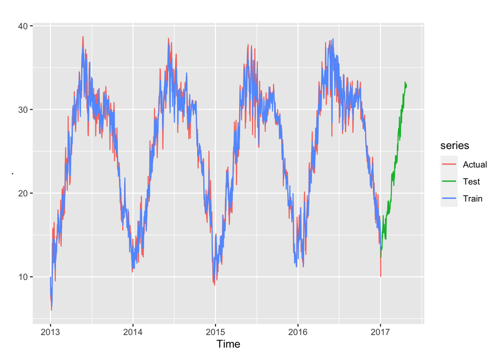

```r
ts_train %>%
  autoplot(series = "Actual") +
  autolayer(climate_stlm_forecast$fitted, series = "Train") +
  autolayer(climate_stlm_forecast$mean, series = "Test")
```

From the analysis above, we can conclude that we have sucsesfully forecast mean temperature and found STLM as the best model with the lowest error (MAPE ~12.15).

# 5 Assumption

## 5.1 No auto-correlation residual

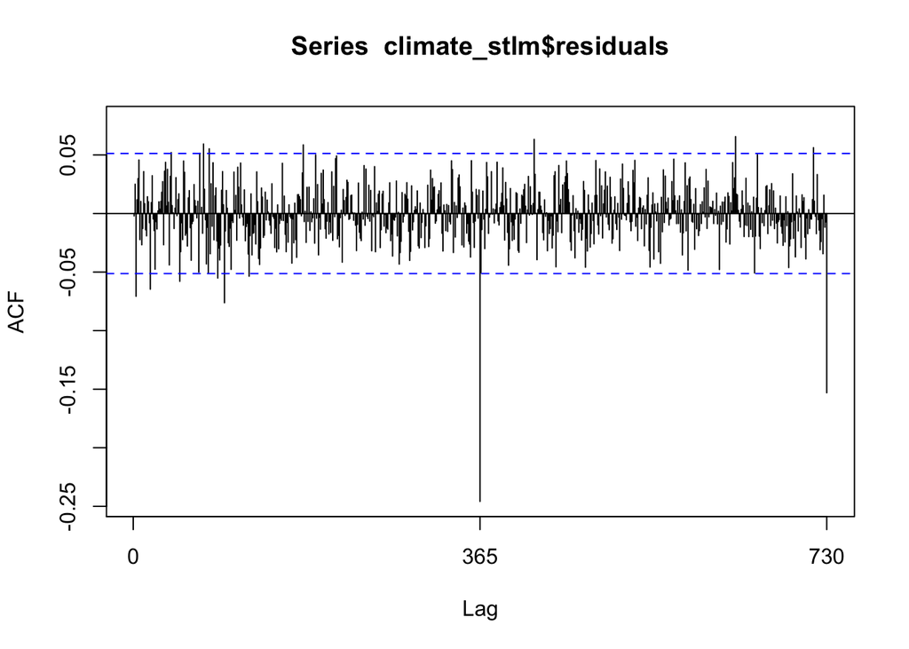

```r
forecast::Acf(climate_stlm$residuals)
```

Based on acf above we can see there are some autocorellation. We have to check more detail our autocorelaltion is significant or not because our mind can trick us. We do Ljung-box test to make sure.

```r
Box.test(climate_stlm$residuals, type = "Ljung-Box")
```

```
##
##  Box-Ljung test
##
## data:  climate_stlm$residuals
## X-squared = 0.0062391, df = 1, p-value = 0.937
```

`p-value >0.05` that means there is no autocorrelation.

## 5.2 Normality residual

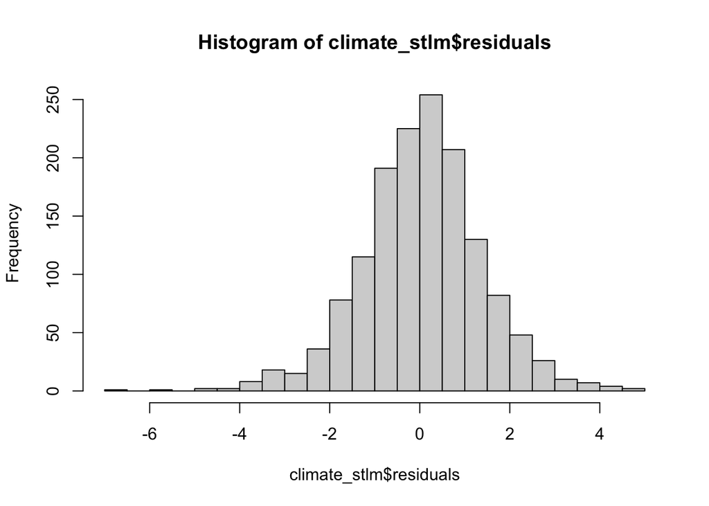

```r
hist(climate_stlm$residuals, breaks = 20)
```

```r
shapiro.test(climate_stlm$residuals)
```

```
##
##  Shapiro-Wilk normality test
##
## data:  climate_stlm$residuals
## W = 0.98986, p-value = 0.00000001546
```

`p-value < 0.05`, our forecast residuals are not distributed normally.

Based on the assumption check, there is no autocorrelation on our forecast residuals (p-value > 0.05), but our forecast’s residuals are not distributed normally, therefore it’s residuals may not be appeared around its mean as seen in the histogram. But, if we inspect the distribution of residuals through a line plot, it is actually resembles the error plot from our time series object decomposition.

In a time series, such errors might emerge from various unpredictable events and is actually quite unavoidable. One strategy to overcome it is to analyze what kinds of unpredictable events that might occur and occurs frequently.